# **Chapter 3: Logistic Regression**

## **3.1 Create a new R Markdown file**

```r
# File 'chapter3.Rmd' is created and linked to index
# access the tidyverse libraries tidyr, dplyr, ggplot2
library(readr); library(dplyr); library(ggplot2); library(tidyr); library(gtsummary)
```

## **3.2 Read Data Files**

```r
# Read the CSV file
alc<- read_csv("data/alc.csv")
colnames(alc)
```

```
##  [1] "school"     "sex"        "age"        "address"    "famsize"
##  [6] "Pstatus"    "Medu"       "Fedu"       "Mjob"       "Fjob"
## [11] "reason"     "guardian"   "traveltime" "studytime"  "schoolsup"
## [16] "famsup"     "activities" "nursery"    "higher"     "internet"
## [21] "romantic"   "famrel"     "freetime"   "goout"      "Dalc"
## [26] "Walc"       "health"     "failures"   "paid"       "absences"
## [31] "G1"         "G2"         "G3"         "alc_use"    "high_use"
```

### About the data

This data is obtained from two secondary education schools in Portugal. it was collected by using school reports and questionnaires.

##### **The data include the following** :

1. **School name**
2. **Demographic data** (Sex, age, address)
3. **Socio-economic Status**( family size, Parent status, Parents education and occupation, and guardians)
4. **Social Data** (extra-curricular activities, romantic relationship, family relationship, free time and going out with friends)
5. **School related feature** :(travel time to school, study time/week , extra support from school and family, extra-paid classe and abscences)
6. **Health status**
7. **Alcohol consumption** : Alcohol consumption in weekdays and weekends. With Average of consumption/week, and categorize them as high consumption (>2 times)
8. **Performance** : It include past class failures and the students’ performance in Mathematics and Portuguese language in 3 period G1 and G2 correspond to the 1st and 2nd period grades and G3 for the final year grade.

## **3.3 Relation between Alcohol consumption and 4 Variables**

```r
# Create a logistic regression model
reg_model <- glm(high_use ~  sex +failures + absences + G3, data = alc, family = "binomial")

# print summary of the model
summary(reg_model)
```

```
##
## Call:
## glm(formula = high_use ~ sex + failures + absences + G3, family = "binomial",
##     data = alc)
##
## Deviance Residuals:
##     Min       1Q   Median       3Q      Max
## -2.1561  -0.8429  -0.5872   1.0033   2.1393
##
## Coefficients:
##             Estimate Std. Error z value Pr(>|z|)
## (Intercept) -1.38733    0.51617  -2.688  0.00719 **
## sexM         1.00870    0.24798   4.068 4.75e-05 ***
## failures     0.50382    0.22018   2.288  0.02213 *
## absences     0.09058    0.02322   3.901 9.56e-05 ***
## G3          -0.04671    0.03948  -1.183  0.23671
## ---
## Signif. codes:  0 '***' 0.001 '**' 0.01 '*' 0.05 '.' 0.1 ' ' 1
##
## (Dispersion parameter for binomial family taken to be 1)
##
##     Null deviance: 452.04  on 369  degrees of freedom
## Residual deviance: 405.59  on 365  degrees of freedom
## AIC: 415.59
##
## Number of Fisher Scoring iterations: 4
```

```r
# Odds Ratio(OR) computation from coefficients
OR<-coef(reg_model) %>% exp

# compute confidence intervals (CI)
CI<- confint(reg_model)%>% exp
# print out the odds ratios with their confidence intervals
cbind(OR, CI)
```

```
##                    OR      2.5 %    97.5 %
## (Intercept) 0.2497422 0.08880747 0.6760545
## sexM        2.7420380 1.69666006 4.4943946
## failures    1.6550376 1.08094265 2.5808643
## absences    1.0948038 1.04844539 1.1486025
## G3          0.9543647 0.88291082 1.0311936
```

## **3.4 Numerical and Graphically explore variables**

#### **3.4.1. Gender relationships with alcohol consumption**

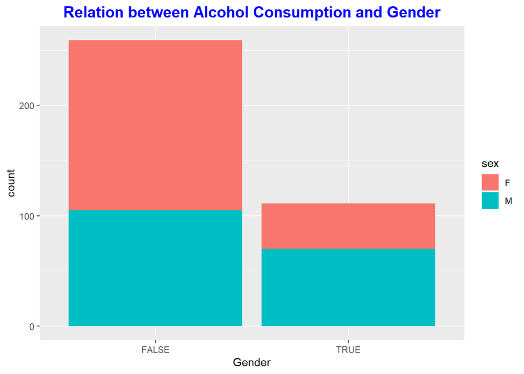

```r
#Bars of high_use and Sex
ggplot(alc, aes(x = high_use,  fill = sex))+ geom_bar() + xlab("Gender")+  ggtitle("Relation between Alcohol Consumption and Gender")+ theme(plot.title = element_text(hjust = 0.5 , size=15, face="bold", color = "blue"))
```

```r
#Summarize high alcohol consumption by gender
 alc %>% select(high_use,sex) %>% tbl_summary(by=c("high_use"),percent = "row")
```

| **Characteristic** | **FALSE**, N = 259<sup>1</sup> | **TRUE**, N = 111<sup>1</sup> |
| --- | --- | --- |
| sex |  |  |
| F | 154 (79%) | 41 (21%) |
| M | 105 (60%) | 70 (40%) |

<sup>1</sup> n (%)

#### **3.4.2. Health relationships with alcohol consumption**

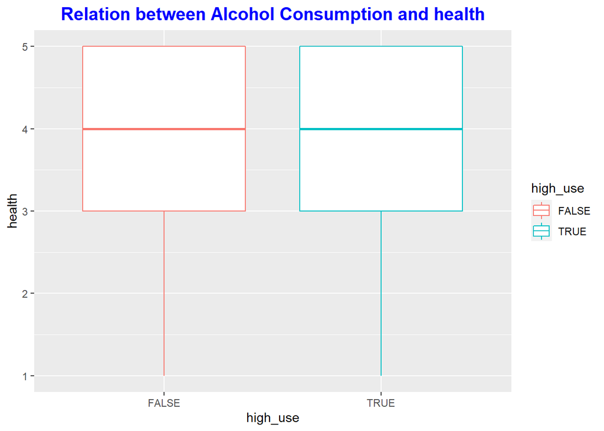

```r
#  Boxplot of high_use and Health
 ggplot(alc, aes(x = high_use, y = health, col = high_use))+ geom_boxplot() +  ggtitle("Relation between Alcohol Consumption and health")+ theme(plot.title = element_text(hjust = 0.5 , size=15, face="bold", color = "blue"));
```

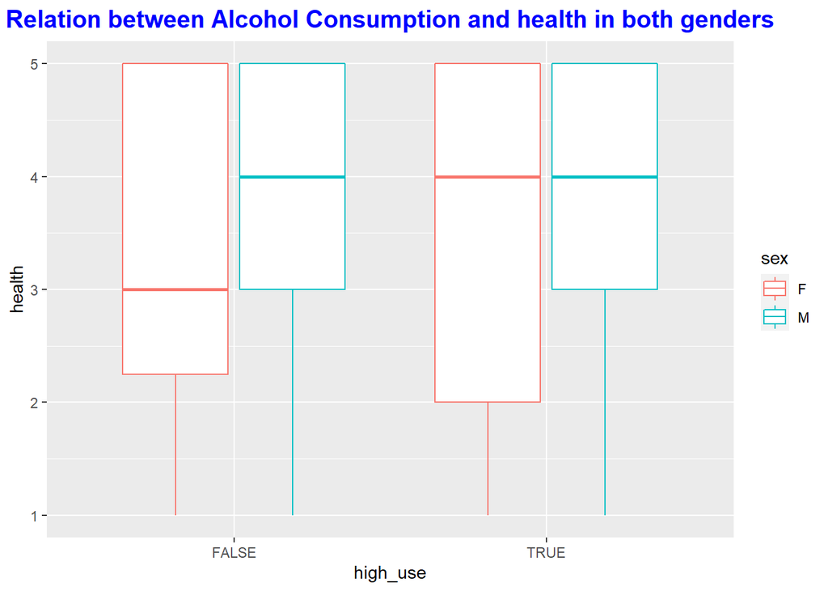

```r
ggplot(alc, aes(x = high_use, y = health, col = sex))+ geom_boxplot() +  ggtitle("Relation between Alcohol Consumption and health in both genders")+ theme(plot.title = element_text(hjust = 0.5 , size=15, face="bold", color = "blue"))
```

```r
#Summarize relation between high alcohol consumption and health in  both genders
alc %>% group_by(sex, high_use) %>% summarise(mean(health),sd(health));
```

[output not shown]

```
## # A tibble: 4 x 4
## # Groups:   sex [2]
##   sex   high_use `mean(health)` `sd(health)`
##   <chr> <lgl>             <dbl>        <dbl>
## 1 F     FALSE              3.37         1.40
## 2 F     TRUE               3.39         1.55
## 3 M     FALSE              3.67         1.41
## 4 M     TRUE               3.93         1.28
```

```r
alc %>% group_by( high_use) %>% summarise(mean(health),sd(health))
```

```
## # A tibble: 2 x 3
##   high_use `mean(health)` `sd(health)`
##   <lgl>             <dbl>        <dbl>
## 1 FALSE              3.49         1.41
## 2 TRUE               3.73         1.40
```

- The overall health score for high alcohol (3.73) is higher than low consumption (3.49) * The results showed that the mean health score for high-use alcohol in males is more than females (the mean health score for females=3.39 , males= 3.92).
- In Males the the difference between low alcohol and high alcohol consumption students was higher in males(low=3.67, high= 3.93)
- In Females group: the difference between low alcohol and high alcohol consumption students was small (low=3.37, high=3.39)
- The results is different from my hypothesis

#### **3.4.3. Absences relationships with alcohol consumption**

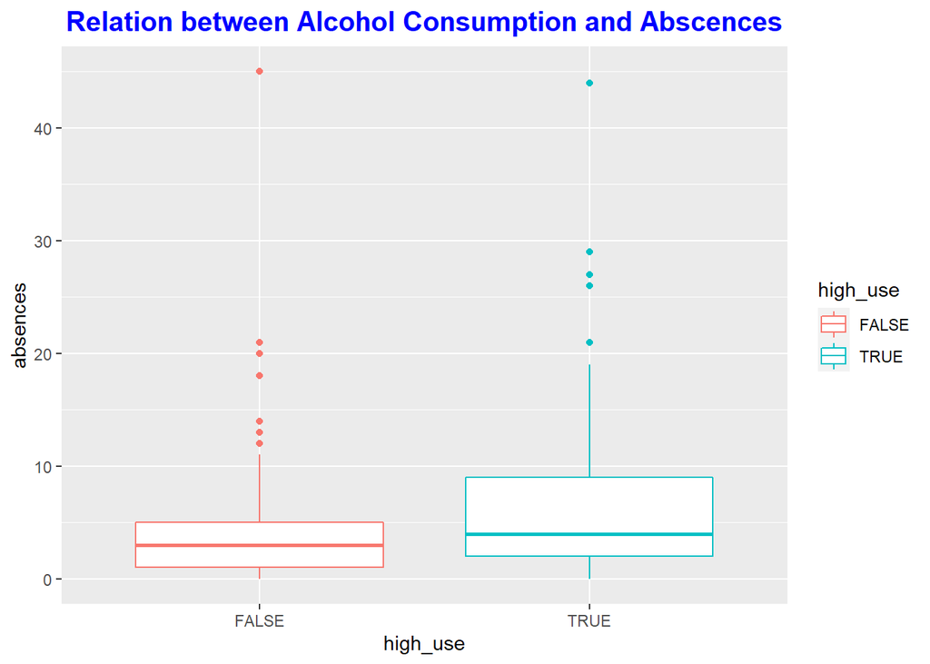

```r
 #  Boxplot of high_use and Absences
 ggplot(alc, aes(x = high_use, y = absences, col = high_use))+ geom_boxplot() +  ggtitle("Relation between Alcohol Consumption and Abscences")+ theme(plot.title = element_text(hjust = 0.5 , size=15, face="bold", color = "blue"));
```

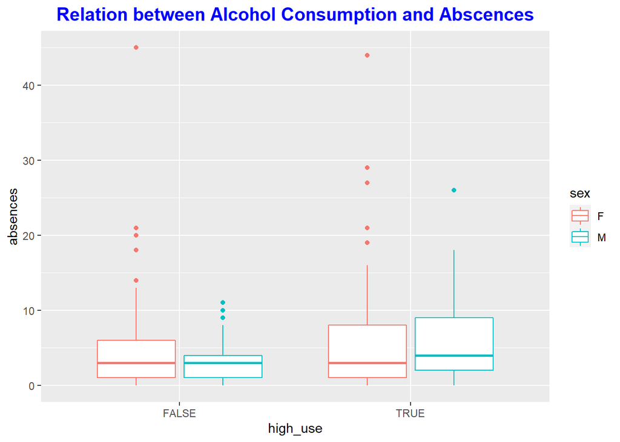

```r
 ggplot(alc, aes(x = high_use, y = absences, col = sex))+ geom_boxplot() +  ggtitle("Relation between Alcohol Consumption and Abscences")+ theme(plot.title = element_text(hjust = 0.5 , size=15, face="bold", color = "blue"))
```

```r
#Summarize relation between high alcohol consumption and absences in  both genders
alc %>% group_by(sex, high_use) %>% summarise(mean(absences),sd(absences));
```

[output not shown]

```
## # A tibble: 4 x 4
## # Groups:   sex [2]
##   sex   high_use `mean(absences)` `sd(absences)`
##   <chr> <lgl>               <dbl>          <dbl>
## 1 F     FALSE                4.25           5.29
## 2 F     TRUE                 6.85           9.40
## 3 M     FALSE                2.91           2.67
## 4 M     TRUE                 6.1            5.29
```

```r
alc %>% group_by( high_use) %>% summarise(mean(absences),sd(absences))
```

```
## # A tibble: 2 x 3
##   high_use `mean(absences)` `sd(absences)`
##   <lgl>               <dbl>          <dbl>
## 1 FALSE                3.71           4.46
## 2 TRUE                 6.38           7.06
```

- The overall abscences in high-use is higher than the low-use group (low=3.7, high=6.4)
- The mean students’ abscences in school among the high-use 6.85 in females and 6.1 in males
- I accept my hypothesis

#### **3.4.3. Grades relationships with alcohol consumption**

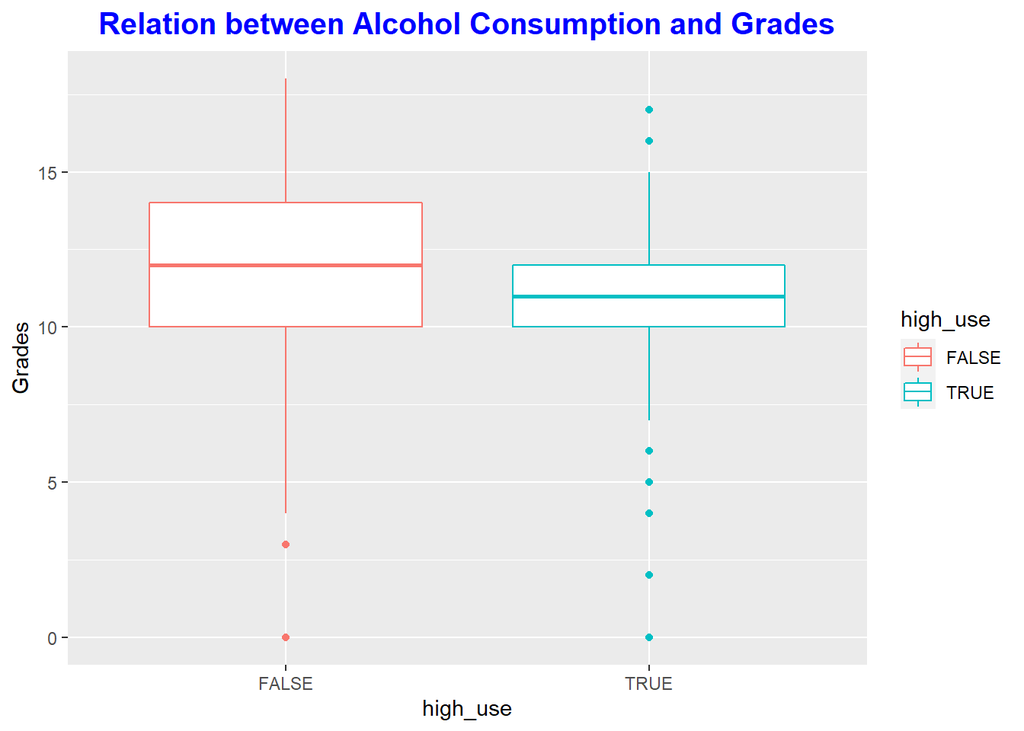

```r
#  Boxplot of high_use and G3
 ggplot(alc, aes(x = high_use, y = G3, col = high_use))+ geom_boxplot() + ylab("Grades")+  ggtitle("Relation between Alcohol Consumption and Grades")+ theme(plot.title = element_text(hjust = 0.5 , size=15, face="bold", color = "blue"));
```

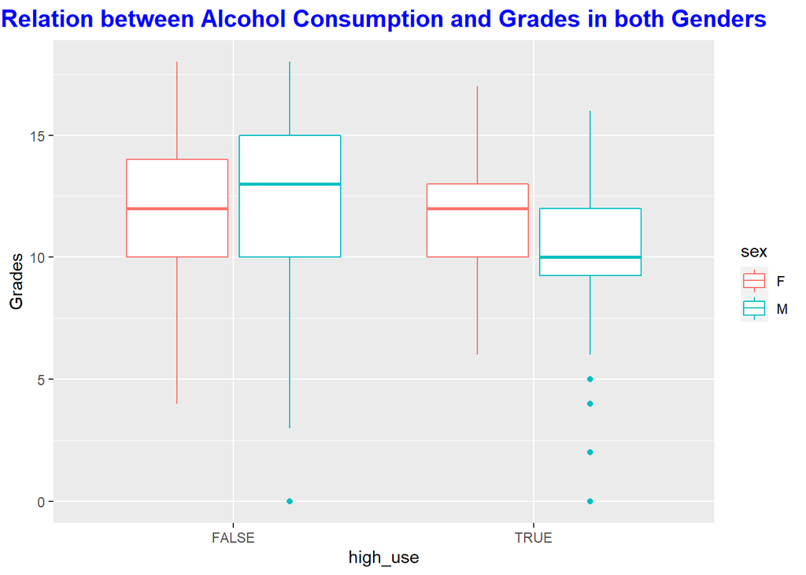

```r
ggplot(alc, aes(x = high_use, y = G3, col = sex))+ geom_boxplot() + ylab("Grades")+  ggtitle("Relation between Alcohol Consumption and Grades in both Genders")+ theme(plot.title = element_text(hjust = 0.5 , size=15, face="bold", color = "blue"))
```

```r
#Summarize relation between high alcohol consumption and Grades in  both genders
alc %>% group_by(sex, high_use) %>% summarise(mean(G3),sd(G3));alc %>% group_by( high_use) %>% summarise(mean(G3),sd(G3))
```

[output not shown]

```
## # A tibble: 4 x 4
## # Groups:   sex [2]
##   sex   high_use `mean(G3)` `sd(G3)`
##   <chr> <lgl>         <dbl>    <dbl>
## 1 F     FALSE          11.4     3.24
## 2 F     TRUE           11.8     2.81
## 3 M     FALSE          12.3     3.45
## 4 M     TRUE           10.3     3.08
```

```
## # A tibble: 2 x 3
##   high_use `mean(G3)` `sd(G3)`
##   <lgl>         <dbl>    <dbl>
## 1 FALSE          11.8     3.35
## 2 TRUE           10.9     3.05
```

- The mean grades for low alcohol consumption is 11.8 while the high alcohol consumption is 10.9 .
- The males showed a large difference between both consumption groups (low=12.3, high=10.3) While the females there was only 0.4 difference (low=11.4 , high=11.8)
- I accept my hypothsis